# R Notebook

1. Load the diamonds.csv data set and undertake an initial exploration of the data. You will find a description of the meanings of the variables on the relevant Kaggle page

```r
library(tidyverse)
library(mosaicData)
library(ggiraphExtra)
library(GGally)
library(janitor)
library(fastDummies)
library(ggfortify)
```

```r
diamonds <- read_csv("diamonds.csv")
view(diamonds)
glimpse(diamonds)
```

```
Rows: 53,940
Columns: 11
$ X1      <dbl> 1, 2, 3, 4, 5, 6, 7, 8, 9, 10, 11, 12, 13, 14, 15, 16, …
$ carat   <dbl> 0.23, 0.21, 0.23, 0.29, 0.31, 0.24, 0.24, 0.26, 0.22, 0…
$ cut     <chr> "Ideal", "Premium", "Good", "Premium", "Good", "Very Go…
$ color   <chr> "E", "E", "E", "I", "J", "J", "I", "H", "E", "H", "J", …
$ clarity <chr> "SI2", "SI1", "VS1", "VS2", "SI2", "VVS2", "VVS1", "SI1…
$ depth   <dbl> 61.5, 59.8, 56.9, 62.4, 63.3, 62.8, 62.3, 61.9, 65.1, 5…
$ table   <dbl> 55, 61, 65, 58, 58, 57, 57, 55, 61, 61, 55, 56, 61, 54,…
$ price   <dbl> 326, 326, 327, 334, 335, 336, 336, 337, 337, 338, 339, …
$ x       <dbl> 3.95, 3.89, 4.05, 4.20, 4.34, 3.94, 3.95, 4.07, 3.87, 4…
$ y       <dbl> 3.98, 3.84, 4.07, 4.23, 4.35, 3.96, 3.98, 4.11, 3.78, 4…
$ z       <dbl> 2.43, 2.31, 2.31, 2.63, 2.75, 2.48, 2.47, 2.53, 2.49, 2…
```

```r
summary(diamonds)
```

```
       X1            carat            cut               color
 Min.   :    1   Min.   :0.2000   Length:53940       Length:53940
 1st Qu.:13486   1st Qu.:0.4000   Class :character   Class :character
 Median :26970   Median :0.7000   Mode  :character   Mode  :character
 Mean   :26970   Mean   :0.7979
 3rd Qu.:40455   3rd Qu.:1.0400
 Max.   :53940   Max.   :5.0100
   clarity              depth           table           price
 Length:53940       Min.   :43.00   Min.   :43.00   Min.   :  326
 Class :character   1st Qu.:61.00   1st Qu.:56.00   1st Qu.:  950
 Mode  :character   Median :61.80   Median :57.00   Median : 2401
                    Mean   :61.75   Mean   :57.46   Mean   : 3933
                    3rd Qu.:62.50   3rd Qu.:59.00   3rd Qu.: 5324
                    Max.   :79.00   Max.   :95.00   Max.   :18823
       x                y                z
 Min.   : 0.000   Min.   : 0.000   Min.   : 0.000
 1st Qu.: 4.710   1st Qu.: 4.720   1st Qu.: 2.910
 Median : 5.700   Median : 5.710   Median : 3.530
 Mean   : 5.731   Mean   : 5.735   Mean   : 3.539
 3rd Qu.: 6.540   3rd Qu.: 6.540   3rd Qu.: 4.040
 Max.   :10.740   Max.   :58.900   Max.   :31.800
```

2. We expect the carat of the diamonds to be strong correlated with the physical dimensions x, y and z. Use ggpairs() to investigate correlations between these four variables.

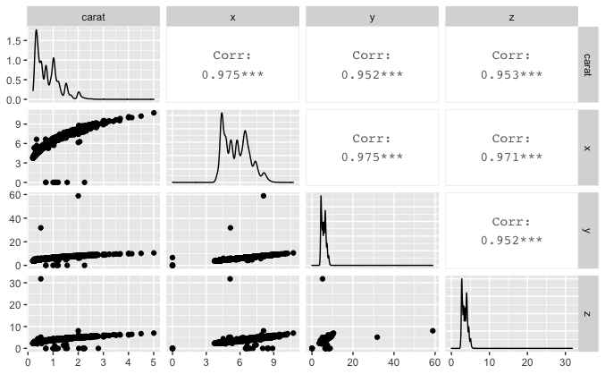

```r
diamonds %>%
  select(carat, x, y, z) %>%
  ggpairs()
```

3. So, we do find significant correlations. Let’s drop columns x, y and z from the dataset, in preparation to use only carat going forward.

```r
diamonds_tidy <- diamonds %>%
  select(-c("X1", "x", "y", "z"))

diamonds_tidy
```

| carat | cut | color | clarity | depth | table | price |
| --- | --- | --- | --- | --- | --- | --- |
| 0.23 | Ideal | E | SI2 | 61.5 | 55.0 | 326 |
| 0.21 | Premium | E | SI1 | 59.8 | 61.0 | 326 |
| 0.23 | Good | E | VS1 | 56.9 | 65.0 | 327 |
| 0.29 | Premium | I | VS2 | 62.4 | 58.0 | 334 |
| 0.31 | Good | J | SI2 | 63.3 | 58.0 | 335 |
| 0.24 | Very Good | J | VVS2 | 62.8 | 57.0 | 336 |
| 0.24 | Very Good | I | VVS1 | 62.3 | 57.0 | 336 |
| 0.26 | Very Good | H | SI1 | 61.9 | 55.0 | 337 |
| 0.22 | Fair | E | VS2 | 65.1 | 61.0 | 337 |
| 0.23 | Very Good | H | VS1 | 59.4 | 61.0 | 338 |

[output cut: 990 more lines]

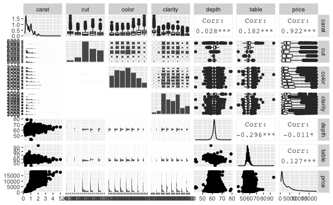

```r
ggpairs(diamonds_tidy)
```

4. We are interested in developing a regression model for the price of a diamond in terms of the possible predictor variables in the dataset.

```r
model <- lm(price ~ carat, data = diamonds)
model
```

```
Call:
lm(formula = price ~ carat, data = diamonds)

Coefficients:
(Intercept)        carat
      -2256         7756
```

4. ii Perform further ggplot visualisations of any significant correlations you find.

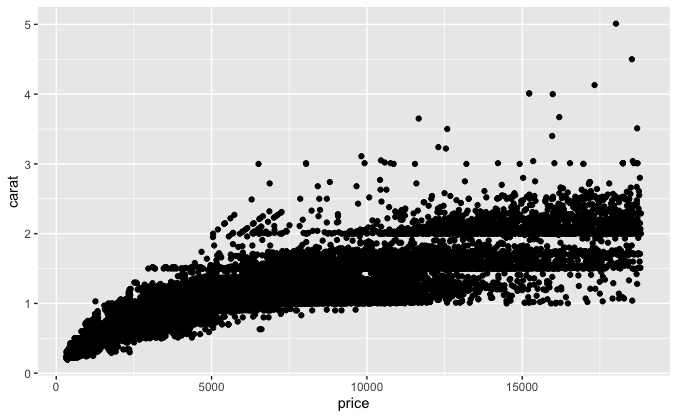

```r
diamonds %>%
  ggplot(aes(x = price, y = carat)) +
  geom_point()
```

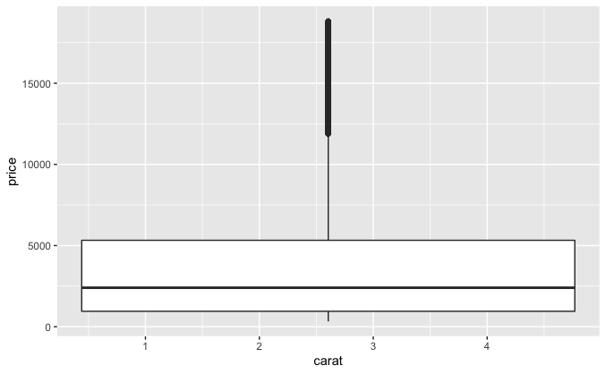

```r
diamonds %>%
  ggplot(aes(x = carat, y = price)) +
  geom_boxplot()
```

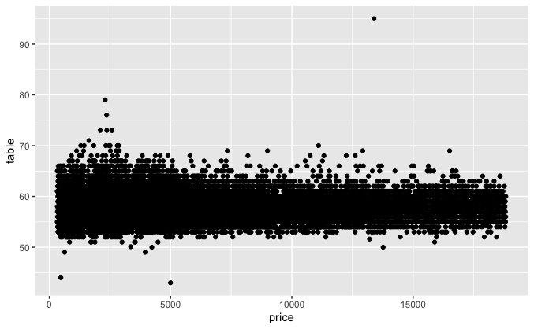

```r
diamonds %>%
  ggplot(aes(x = price, y = table)) +
  geom_point()
```

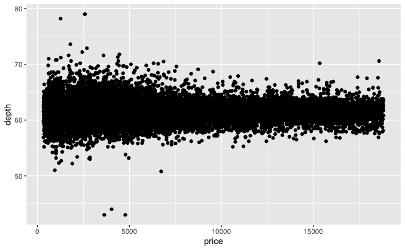

```r
diamonds %>%
  ggplot(aes(x = price, y = depth)) +
  geom_point()
```

5. Shortly we may try a regression fit using one or more of the categorical predictors cut, clarity and color, so let’s investigate these predictors:

```r
diamonds_dummy <- diamonds %>%
  dummy_cols(select_columns = c("cut", "clarity", "color"), remove_first_dummy = T) %>%
  clean_names()
diamonds_dummy
```

| x1 | carat | cut | color | clarity | depth | table | price | cut_good | cut_ideal | cut_premium | cut_very_good | clarity_if | clarity_si1 | clarity_si2 | clarity_vs1 | clarity_vs2 | clarity_vvs1 | clarity_vvs2 | color_e | color_f | color_g | color_h | color_i | color_j |
| --- | --- | --- | --- | --- | --- | --- | --- | --- | --- | --- | --- | --- | --- | --- | --- | --- | --- | --- | --- | --- | --- | --- | --- | --- |
| 1 | 0.23 | Ideal | E | SI2 | 61.5 | 55.0 | 326 | 0 | 1 | 0 | 0 | 0 | 0 | 1 | 0 | 0 | 0 | 0 | 1 | 0 | 0 | 0 | 0 | 0 |
| 2 | 0.21 | Premium | E | SI1 | 59.8 | 61.0 | 326 | 0 | 0 | 1 | 0 | 0 | 1 | 0 | 0 | 0 | 0 | 0 | 1 | 0 | 0 | 0 | 0 | 0 |
| 3 | 0.23 | Good | E | VS1 | 56.9 | 65.0 | 327 | 1 | 0 | 0 | 0 | 0 | 0 | 0 | 1 | 0 | 0 | 0 | 1 | 0 | 0 | 0 | 0 | 0 |
| 4 | 0.29 | Premium | I | VS2 | 62.4 | 58.0 | 334 | 0 | 0 | 1 | 0 | 0 | 0 | 0 | 0 | 1 | 0 | 0 | 0 | 0 | 0 | 0 | 1 | 0 |
| 5 | 0.31 | Good | J | SI2 | 63.3 | 58.0 | 335 | 1 | 0 | 0 | 0 | 0 | 0 | 1 | 0 | 0 | 0 | 0 | 0 | 0 | 0 | 0 | 0 | 1 |
| 6 | 0.24 | Very Good | J | VVS2 | 62.8 | 57.0 | 336 | 0 | 0 | 0 | 1 | 0 | 0 | 0 | 0 | 0 | 0 | 1 | 0 | 0 | 0 | 0 | 0 | 1 |
| 7 | 0.24 | Very Good | I | VVS1 | 62.3 | 57.0 | 336 | 0 | 0 | 0 | 1 | 0 | 0 | 0 | 0 | 0 | 1 | 0 | 0 | 0 | 0 | 0 | 1 | 0 |
| 8 | 0.26 | Very Good | H | SI1 | 61.9 | 55.0 | 337 | 0 | 0 | 0 | 1 | 0 | 1 | 0 | 0 | 0 | 0 | 0 | 0 | 0 | 0 | 1 | 0 | 0 |
| 9 | 0.22 | Fair | E | VS2 | 65.1 | 61.0 | 337 | 0 | 0 | 0 | 0 | 0 | 0 | 0 | 0 | 1 | 0 | 0 | 1 | 0 | 0 | 0 | 0 | 0 |
| 10 | 0.23 | Very Good | H | VS1 | 59.4 | 61.0 | 338 | 0 | 0 | 0 | 1 | 0 | 0 | 0 | 1 | 0 | 0 | 0 | 0 | 0 | 0 | 1 | 0 | 0 |

[output cut: 990 more lines]

```r
lm(price ~ carat, data = diamonds)
```

```
Call:
lm(formula = price ~ carat, data = diamonds)

Coefficients:
(Intercept)        carat
      -2256         7756
```

[output not shown]

[figure not shown]

```r
par(mfrow = c(2,2))
plot(diamonds)
```

rough work

```r
model1 <- lm(price ~ carat + clarity + carat:clarity, data = diamonds)

summary(model1)
```

```
Call:
lm(formula = price ~ carat + clarity + carat:clarity, data = diamonds)

Residuals:
    Min      1Q  Median      3Q     Max
-8912.0  -604.1   -23.8   532.8  9459.0

Coefficients:
                  Estimate Std. Error t value Pr(>|t|)
(Intercept)       -1480.56     100.30  -14.76   <2e-16 ***
carat              4209.79      70.09   60.06   <2e-16 ***
clarityIF         -1526.88     113.95  -13.40   <2e-16 ***
claritySI1        -1404.14     102.81  -13.66   <2e-16 ***
claritySI2        -1937.78     104.43  -18.55   <2e-16 ***
clarityVS1        -1224.94     103.74  -11.81   <2e-16 ***
clarityVS2        -1184.27     102.60  -11.54   <2e-16 ***
clarityVVS1       -1265.73     107.62  -11.76   <2e-16 ***
clarityVVS2       -1243.75     105.53  -11.79   <2e-16 ***
carat:clarityIF    7415.65     114.83   64.58   <2e-16 ***
carat:claritySI1   3880.55      73.92   52.50   <2e-16 ***
carat:claritySI2   3660.46      74.20   49.33   <2e-16 ***
carat:clarityVS1   4790.93      76.84   62.34   <2e-16 ***
carat:clarityVS2   4416.36      74.22   59.50   <2e-16 ***
carat:clarityVVS1  6259.46      96.68   64.74   <2e-16 ***
carat:clarityVVS2  5867.39      84.45   69.48   <2e-16 ***
---
Signif. codes:  0 ‘***’ 0.001 ‘**’ 0.01 ‘*’ 0.05 ‘.’ 0.1 ‘ ’ 1

Residual standard error: 1206 on 53924 degrees of freedom
Multiple R-squared:  0.9087,    Adjusted R-squared:  0.9086
F-statistic: 3.576e+04 on 15 and 53924 DF,  p-value: < 2.2e-16
```